# Using `infer` package for Statistical Inference

Francisco Cruz (francruz)

1/2/2020

## Data Preparation

I will use `nycflights13` to support several typical statistical tests. `dplyr` will also be used extensively to integrate the full workflow within the `tidyverse` grammar.

First, we prepare a dataframe with the following structure, allowing us to perform the most typical statistical analyses:

- Two numeric: `arr_delay`, `dep_delay`
- Two categorical:
  - `season` (`winter`, `summer`)
  - `day_hour` (`morning`, `not morning`)
- Three categorical: `origin` (`EWR`, `JFK`, `LGA`)
- Sixteen categorical: `carrier`

```r
fli_small <- flights %>%
    na.omit() %>%
    sample_n(size = 500) %>%
    mutate(season = case_when(month %in% c(10:12, 1:3) ~ 'winter',
                              month %in% c(4:9) ~ 'summer')) %>%
    mutate(day_hour = case_when(between(hour, 1, 12) ~'morning',
                                between(hour, 13,24) ~'not morning')) %>%     select(arr_delay, dep_delay, season, day_hour, origin, carrier)
```

## Hypothesis Tests

### One Numerical Value (mean)

Let’s look at the mean of the departure delay of flights in our dataset. We can clculate this value in different ways; here are just a few. Notice that the last one makes use of the `infer` package:

```r
x_bar <- mean(fli_small[['dep_delay']])
x_bar <- mean(fli_small$dep_delay)

(x_bar <- fli_small %>%
        specify(response = dep_delay) %>%
        calculate(stat = 'mean'))
```

```
## # A tibble: 1 x 1
##    stat
##   <dbl>
## 1  10.8
```

```r
null_dist <- fli_small %>%
    specify(response = dep_delay) %>%
    hypothesize(null = 'point', mu = 10) %>%
    generate(reps = 1000) %>%
    calculate(stat = 'mean')
```

```
## Setting `type = "bootstrap"` in `generate()`.
```

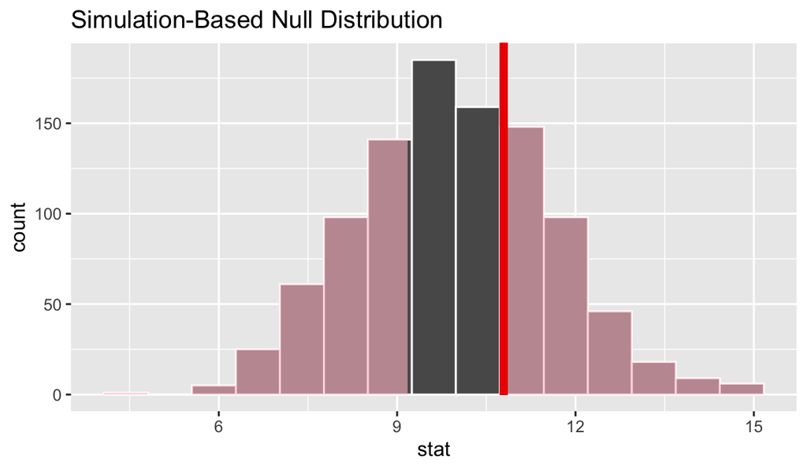

```r
visualize(null_dist) +
    shade_p_value(obs_stat = x_bar,
                  direction = 'two_sided')
```

```r
significance <- null_dist  %>%
    get_p_value(obs_stat = x_bar, direction = 'two_sided')
```

Notice that the grammar follows the inferential workflow: we `specify` the value over which we are running the test, and `hypothesize` our null $H_{0}: \mu = 10$. Next, we `generate` 1000 replicates of this null hypotesis and `calculate` the mean `dep_delay` for each one.

We use `visualize` as a wrapper for `ggplot` to visualize our test, and since our null is expressed as an equality, the test is `two-sided` to represent the alternate hypothesis $H_{a} \neq 0$. Passing the observed mean as `obs_stat = x_bar` sets the critical point for the test.

Finally, `get_p_value` outputs the significance of the test. In this case we obtain a value of 0.626 which is greater than 0.05, so we don’t have evidence to reject our null hypothesis that the average departure delay is 10 minutes.

### One Numerical Variable (standardized mean $t$)

Reproducing a similar analysis, but this time applying the test over the standardized mean, and testing against the null hypothesis $H_{0}: \mu = 8$

```r
(t_bar <- fli_small %>%
        t_stat(response = dep_delay, mu = 8))
```

```
## [1] 1.751
```

Following the same workflow:

```r
null_dist <- fli_small %>%
    specify(response = dep_delay) %>%
    hypothesize(null = 'point', mu = 8) %>%
    generate(reps = 1000) %>%
    calculate(stat = 't')
```

```
## Setting `type = "bootstrap"` in `generate()`.
```

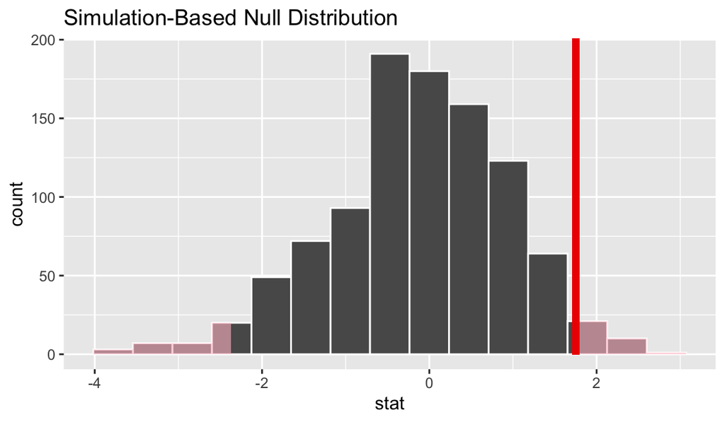

```r
visualize(null_dist) +
    shade_p_value(obs_stat = t_bar,
                  direction = 'two_sided')
```

```r
significance <- null_dist  %>%
    get_p_value(obs_stat = t_bar, direction = 'two_sided')
```

In this case we obtain a p-value of 0.054 which is just barely greater than 0.05.

### One Numerical Variable (median)

As usual, we first calculate the statistic from our sample

```r
(x_tilde <- fli_small %>%
     specify(response = dep_delay) %>%
     calculate(stat = 'median') %>%
     pull())
```

```
## [1] -2
```

And now calculate the value of the stat across 1000 replicates to represent our null hypothesis, $H_{0}: \tilde{x} = -1$.

```r
null_dist <- fli_small %>%
    specify(response = dep_delay) %>%
    hypothesize(null = 'point', med = -1) %>%
    generate(reps = 1000) %>%
    calculate(stat = 'median')
```

```
## Setting `type = "bootstrap"` in `generate()`.
```

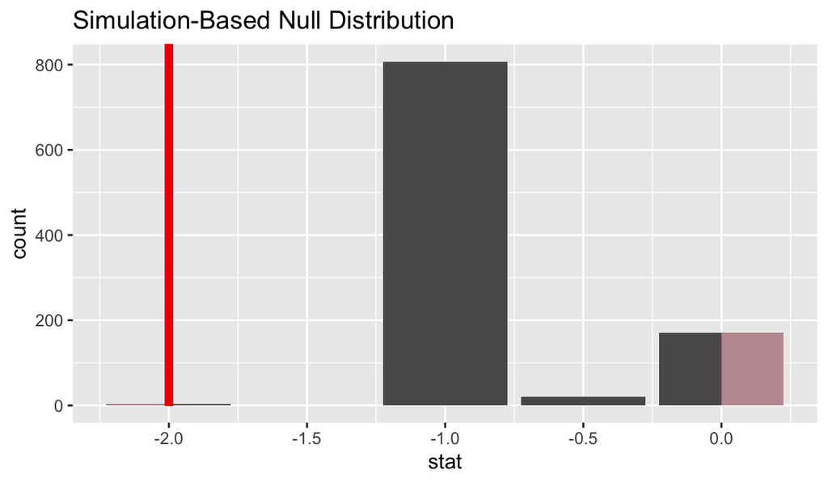

```r
visualize(null_dist) +
    shade_p_value(obs_stat = x_tilde, direction = 'two_sided')
```

And the p-value is calculated as:

```r
significance <- null_dist %>%
    get_p_value(obs_stat = x_tilde, direction = 'two_sided') %>%
    pull()
```

giving a value of 0.006, which allows us to reject the null hypothesis and affirm that a median of -1 is unlikely given the sample distribution.

### One Categorical (a proportion)

```r
(p_hat <- fli_small %>%
     specify(response = day_hour, success = 'morning') %>%
     calculate(stat = 'prop'))
```

```
## # A tibble: 1 x 1
##    stat
##   <dbl>
## 1 0.428
```